# Machine Learning Final Project: Prediction Assignment Writeup

Julie Ramirez

17/6/2021

# Background.

Using devices such as Jawbone Up, Nike FuelBand, and Fitbit it is now possible to collect a large amount of data about personal activity relatively inexpensively. These type of devices are part of the quantified self movement – a group of enthusiasts who take measurements about themselves regularly to improve their health, to find patterns in their behavior, or because they are tech geeks. One thing that people regularly do is quantify how much of a particular activity they do, but they rarely quantify how well they do it. In this project, your goal will be to use data from accelerometers on the belt, forearm, arm, and dumbell of 6 participants. They were asked to perform barbell lifts correctly and incorrectly in 5 different ways. More information is available from the website here:

http://web.archive.org/web/20161224072740/http:/groupware.les.inf.puc-rio.br/har

(see the section on the Weight Lifting Exercise Dataset).

# Data.

The training data for this project are available here:

https://d396qusza40orc.cloudfront.net/predmachlearn/pml-training.csv

The test data are available here:

https://d396qusza40orc.cloudfront.net/predmachlearn/pml-testing.csv

The data for this project come from this source:

http://web.archive.org/web/20161224072740/http:/groupware.les.inf.puc-rio.br/har.

If you use the document you create for this class for any purpose please cite them as they have been very generous in allowing their data to be used for this kind of assignment.

# A short description of the datasets.

“Six young health participants were asked to perform one set of 10 repetitions of the Unilateral Dumbbell Biceps Curl in five different fashions: exactly according to the specification (Class A), throwing the elbows to the front (Class B), lifting the dumbbell only halfway (Class C), lowering the dumbbell only halfway (Class D) and throwing the hips to the front (Class E).

Class A corresponds to the specified execution of the exercise, while the other 4 classes correspond to common mistakes. Participants were supervised by an experienced weight lifter to make sure the execution complied to the manner they were supposed to simulate. The exercises were performed by six male participants aged between 20-28 years, with little weight lifting experience. We made sure that all participants could easily simulate the mistakes in a safe and controlled manner by using a relatively light dumbbell (1.25kg)."

# load libraries.

```r
library(knitr)
library(caret)
library(rattle)
library(ggplot2)
library(lattice)
set.seed(12345)
```

# Getting Data.

```r
# Getting data

urltesting<-"https://d396qusza40orc.cloudfront.net/predmachlearn/pml-testing.csv"
urltraining<-"https://d396qusza40orc.cloudfront.net/predmachlearn/pml-training.csv"
```

```r
# load data to memory

download.file(url=urltraining, destfile="training.csv")
download.file(url=urltesting, destfile="testing.csv")
```

```r
train <- read.csv("training.csv", na.strings=c("NA","#DIV/0!",""))
dim(train)
```

```
## [1] 19622   160
```

```r
test <- read.csv("testing.csv", na.strings=c("NA","#DIV/0!",""))
dim(test)
```

```
## [1]  20 160
```

# Cleaning Data.

```r
# remove variables with Nearly Zero Variance
NZV <- nearZeroVar(train)   # function of caret
train <- train[, -NZV]
dim(train)
```

```
## [1] 19622   124
```

With the cleaning process above, the number of variables for the analysis has been reduced to 124.

```r
train <- train[, -c(1:6)]
```

As the first 6 predictors have little predicting power, these are eliminated in the the train sets. The number of variables for the analysis has been reduced to 118.

```r
train<-train[, colSums(is.na(train)) == 0]
dim(train)
```

```
## [1] 19622    53
```

# Partition with the train dataset.

```r
intrain <- createDataPartition(y=train$classe, p=0.7, list=FALSE)
dat_train <- train[intrain, ]
dat_test <- train[-intrain, ]
```

```r
dim(dat_test)
```

```
## [1] 5885   53
```

```r
dim(dat_train)
```

```
## [1] 13737    53
```

# Method: Random Forest.

```r
controlRF <- trainControl(method="cv", number=5, verboseIter=FALSE)
modFitRF<- train(classe ~ ., data=dat_train, method="rf",
                          trControl=controlRF)
modFitRF$finalModel
```

```
##
## Call:
##  randomForest(x = x, y = y, mtry = min(param$mtry, ncol(x)))
##                Type of random forest: classification
##                      Number of trees: 500
## No. of variables tried at each split: 2
##
##         OOB estimate of  error rate: 0.71%
## Confusion matrix:
##      A    B    C    D    E class.error
## A 3901    3    0    1    1 0.001280082
## B   18 2633    7    0    0 0.009405568
## C    0   23 2371    2    0 0.010434057
## D    0    0   31 2218    3 0.015097691
## E    0    0    2    6 2517 0.003168317
```

```r
modFitRF
```

```
## Random Forest
##
## 13737 samples
##    52 predictor
##     5 classes: 'A', 'B', 'C', 'D', 'E'
##
## No pre-processing
## Resampling: Cross-Validated (5 fold)
## Summary of sample sizes: 10987, 10990, 10990, 10991, 10990
## Resampling results across tuning parameters:
##
##   mtry  Accuracy   Kappa
##    2    0.9911914  0.9888567
##   27    0.9902453  0.9876601
##   52    0.9846405  0.9805695
##
## Accuracy was used to select the optimal model using the largest value.
## The final value used for the model was mtry = 2.
```

```r
# prediction on dat_test dataset
predictRF <- predict(modFitRF, newdata=dat_test)

dat_test$classe<-as.factor(dat_test$classe)

confusionmatrixRF <- confusionMatrix(predictRF, dat_test$classe)
confusionmatrixRF
```

```
## Confusion Matrix and Statistics
##
##           Reference
## Prediction    A    B    C    D    E
##          A 1673    4    0    0    0
##          B    1 1135    8    0    0
##          C    0    0 1017   22    0
##          D    0    0    1  940    1
##          E    0    0    0    2 1081
##
## Overall Statistics
##
##                Accuracy : 0.9934
##                  95% CI : (0.991, 0.9953)
##     No Information Rate : 0.2845
##     P-Value [Acc > NIR] : < 2.2e-16
##
##                   Kappa : 0.9916
##
##  Mcnemar's Test P-Value : NA
##
## Statistics by Class:
##
##                      Class: A Class: B Class: C Class: D Class: E
## Sensitivity            0.9994   0.9965   0.9912   0.9751   0.9991
## Specificity            0.9991   0.9981   0.9955   0.9996   0.9996
## Pos Pred Value         0.9976   0.9921   0.9788   0.9979   0.9982
## Neg Pred Value         0.9998   0.9992   0.9981   0.9951   0.9998
## Prevalence             0.2845   0.1935   0.1743   0.1638   0.1839
## Detection Rate         0.2843   0.1929   0.1728   0.1597   0.1837
## Detection Prevalence   0.2850   0.1944   0.1766   0.1601   0.1840
## Balanced Accuracy      0.9992   0.9973   0.9934   0.9873   0.9993
```

```r
predictFinalRF<- predict(modFitRF, test)
predictFinalRF
```

```
##  [1] B A B A A E D B A A B C B A E E A B B B
## Levels: A B C D E
```

# Method: Decision Tree.

```r
modFit_DecisionTree<-train(classe ~ ., data=dat_train, method="rpart")
modFit_DecisionTree
```

```
## CART
##
## 13737 samples
##    52 predictor
##     5 classes: 'A', 'B', 'C', 'D', 'E'
##
## No pre-processing
## Resampling: Bootstrapped (25 reps)
## Summary of sample sizes: 13737, 13737, 13737, 13737, 13737, 13737, ...
## Resampling results across tuning parameters:
##
##   cp          Accuracy   Kappa
##   0.03458448  0.5156694  0.37076268
##   0.06092971  0.4272020  0.22787636
##   0.11595972  0.3385655  0.08323443
##
## Accuracy was used to select the optimal model using the largest value.
## The final value used for the model was cp = 0.03458448.
```

```r
modFit_DecisionTree$finalModel
```

```
## n= 13737
##
## node), split, n, loss, yval, (yprob)
##       * denotes terminal node
##
##  1) root 13737 9831 A (0.28 0.19 0.17 0.16 0.18)
##    2) roll_belt< 130.5 12577 8681 A (0.31 0.21 0.19 0.18 0.11)
##      4) pitch_forearm< -33.95 1107    9 A (0.99 0.0081 0 0 0) *
##      5) pitch_forearm>=-33.95 11470 8672 A (0.24 0.23 0.21 0.2 0.12)
##       10) magnet_dumbbell_y< 439.5 9738 6992 A (0.28 0.18 0.24 0.19 0.11)
##         20) roll_forearm< 123.5 6030 3573 A (0.41 0.18 0.18 0.17 0.062) *
##         21) roll_forearm>=123.5 3708 2471 C (0.078 0.18 0.33 0.23 0.18) *
##       11) magnet_dumbbell_y>=439.5 1732  831 B (0.03 0.52 0.041 0.22 0.19) *
##    3) roll_belt>=130.5 1160   10 E (0.0086 0 0 0 0.99) *
```

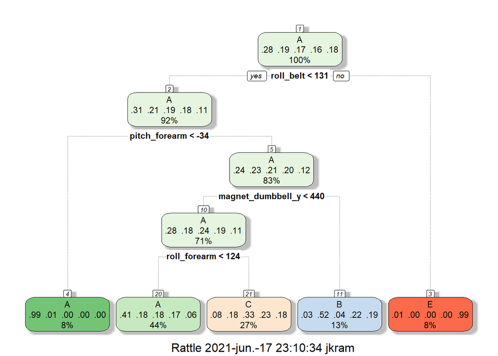

```r
# plot Tree

fancyRpartPlot(modFit_DecisionTree$finalModel)
```

```r
# Predicting new values

predict_DecisionTree <- predict(modFit_DecisionTree, newdata=dat_test)
```

```r
confusionmatrix_DeciTree <- confusionMatrix(predict_DecisionTree, dat_test$classe)
confusionmatrix_DeciTree
```

```
## Confusion Matrix and Statistics
##
##           Reference
## Prediction    A    B    C    D    E
##          A 1525  484  499  423  153
##          B   29  385   37  187  159
##          C  116  270  490  354  289
##          D    0    0    0    0    0
##          E    4    0    0    0  481
##
## Overall Statistics
##
##                Accuracy : 0.4895
##                  95% CI : (0.4767, 0.5024)
##     No Information Rate : 0.2845
##     P-Value [Acc > NIR] : < 2.2e-16
##
##                   Kappa : 0.3324
##
##  Mcnemar's Test P-Value : NA
##
## Statistics by Class:
##
##                      Class: A Class: B Class: C Class: D Class: E
## Sensitivity            0.9110  0.33802  0.47758   0.0000  0.44455
## Specificity            0.6298  0.91319  0.78823   1.0000  0.99917
## Pos Pred Value         0.4945  0.48306  0.32258      NaN  0.99175
## Neg Pred Value         0.9468  0.85181  0.87723   0.8362  0.88870
## Prevalence             0.2845  0.19354  0.17434   0.1638  0.18386
## Detection Rate         0.2591  0.06542  0.08326   0.0000  0.08173
## Detection Prevalence   0.5240  0.13543  0.25811   0.0000  0.08241
## Balanced Accuracy      0.7704  0.62560  0.63291   0.5000  0.72186
```

From the confusion matrix, the accuracy rate is 0.49, and so the out-of-sample error rate is 0.5. Using classification tree does not predict the outcome classe very well.